# Week9 Tutorial - Decision Tree

22/3/2021

```r
# Import libraries
library(DataExplorer)
library(missForest)
library(tidyverse)
library(reshape2)
library(ggplot2)
library(caTools)
library(caret)
library(e1071)
library(psych)
library(RCurl)
library(ROCR)
library(mice)
library(VIM)
```

```r
# Libraries for decision tree models
library(rpart)
library(rpart.plot)
library(party)
```

## 1. Dataset Description

### 1.1 General Information

#### Dataset: https://www.kaggle.com/fernandolima23/classification-in-asteroseismology

#### Reference: https://www.kaggle.com/jetakow/logistic-regression-test-auc-0-991-acc-0-95

This dataset contains different measures of stars. Our goal is to classify the stars into two categories (RGB-HeB classification) based on these measures.

- Feature number: 4
- Instance number: 1001

### 1.2 Independent Variables

1. Dnu F8.5 (uHz) (Continuous variable): ‘Mean large frequency separation of modes with the same degree and consecutive order’.
2. Numax F9.5 (uHz) (Continuous variable): ‘Frequency of maximum oscillation power’.
3. Epsilon F7.3 (Continuous variable): ‘Location of the mode’.

### 1.3 Dependent Variables

1. Pop (Categorical variable): HeB (1), RGB (0).
- RGB (Red Giant Branch): the portion of the giant branch before helium ignition occurs in the course of stellar evolution.
- HeB (Helium Burning): the fusion of helium in the contracted core of a red giant star at extremely high temperatures, hotter than those reached in the Sun.

```r
# Load data
df <- read.csv('classification_in_asteroseismology.csv', header = T)
```

## 3. Dataset Overview

```r
summary(df)
```

```
      POP              Dnu             numax           epsilon
 Min.   :0.0000   Min.   : 2.500   Min.   : 17.98   Min.   :0.0050
 1st Qu.:0.0000   1st Qu.: 4.073   1st Qu.: 32.92   1st Qu.:0.2200
 Median :1.0000   Median : 4.309   Median : 38.29   Median :0.8150
 Mean   :0.7123   Mean   : 5.775   Mean   : 58.44   Mean   :0.6108
 3rd Qu.:1.0000   3rd Qu.: 6.580   3rd Qu.: 70.14   3rd Qu.:0.8900
 Max.   :1.0000   Max.   :17.699   Max.   :239.65   Max.   :1.0000
```

```r
# Dataset info
str(df)
```

```
'data.frame':   1001 obs. of  4 variables:
 $ POP    : int  1 0 1 1 0 1 1 0 1 1 ...
 $ Dnu    : num  4.45 6.94 2.65 4.24 10.45 ...
 $ numax  : num  43.1 74.1 21.6 32.1 120.4 ...
 $ epsilon: num  0.985 0.15 0.855 0.84 0.275 0.945 0.985 0.215 0.885 0.855 ...
```

## 4. Data Imputation

```r
# Prior to treating missing values any blanks in the data set must be converted to NA.
df <- mutate_all(df, na_if, "")
```

### 4.1 Plot Missing Values

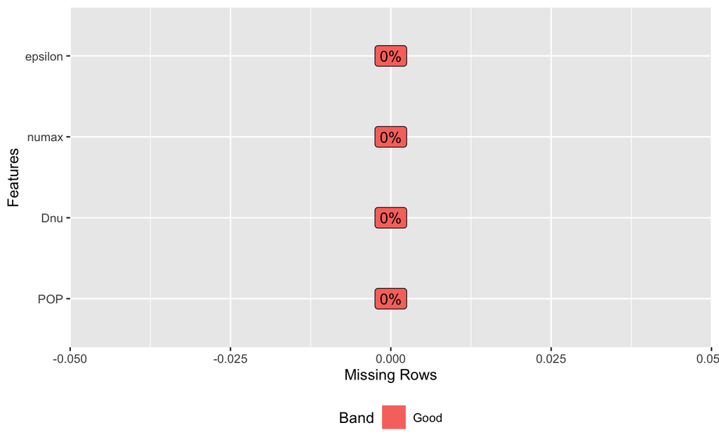

```r
# Viewing and counting missing data using DataExplorer package.
plot_missing(df)
```

Good News, there is no missing value now.

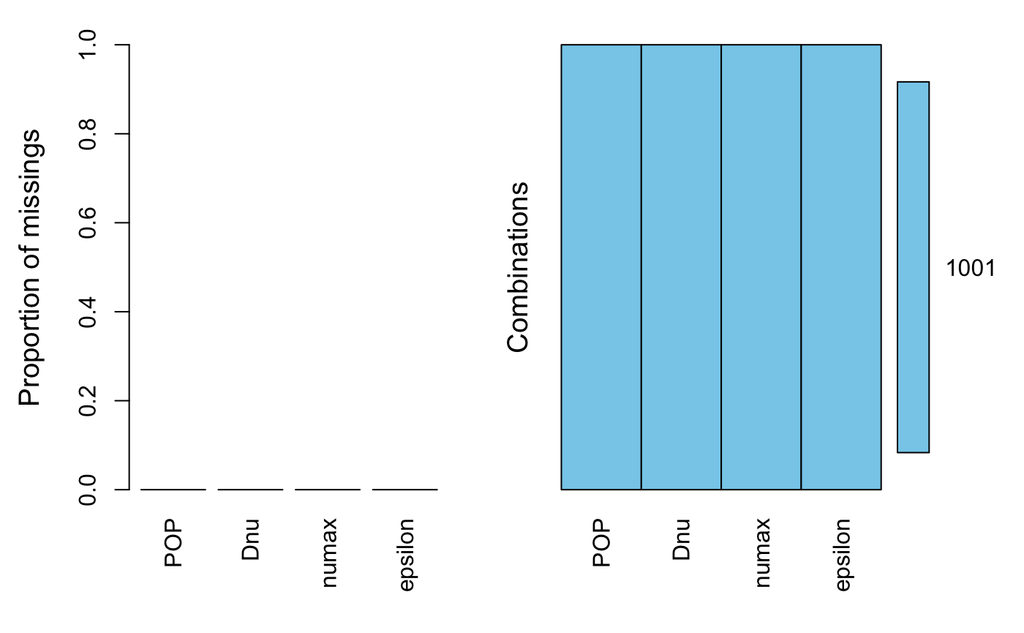

```r
# Using VIM library
vim_plot <- aggr(df, numbers=TRUE, prop = c(TRUE, FALSE))
```

As we can see, we have 1001 records in total, and no missing value in this data set.

This function plots and calculates the amount of missing values in each variable and in certain combinations. On the right-hand chart, we can see the missing values’ distribution in a combination. Notice that left-hand chart uses proportions as Y-axis, while the right one uses real number because we set prop = c(TRUE, FALSE).

```
 /\     /\
{  `---'  }
{  O   O  }
==>  V <==  No need for mice. This data set is completely observed.
 \  \|/  /
  `-----'

     POP Dnu numax epsilon
1001   1   1     1       1 0
       0   0     0       0 0
```

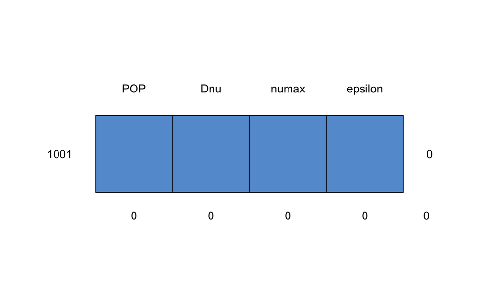

```r
# Using mice library
md.pattern(df)
```

This chart demonstrates the distribution of missing values. The values on the left side represent different groups of the data set. The values on the right side represent the total number of variables that contain missing value. The top line are names of different variables. The bottom line represents the number of missing values of each variable.

```r
# Overview of new data set
sum(is.na(df))
```

```
[1] 0
```

```r
head(df, 10)
```

|  | POP | Dnu | numax | epsilon |
| --- | --- | --- | --- | --- |
| 1 | 1 | 4.44780 | 43.06289 | 0.985 |
| 2 | 0 | 6.94399 | 74.07646 | 0.150 |
| 3 | 1 | 2.64571 | 21.57891 | 0.855 |
| 4 | 1 | 4.24168 | 32.13189 | 0.840 |
| 5 | 0 | 10.44719 | 120.37356 | 0.275 |
| 6 | 1 | 4.31470 | 37.59315 | 0.945 |
| 7 | 1 | 4.46724 | 46.71595 | 0.985 |
| 8 | 0 | 7.63714 | 87.44575 | 0.215 |
| 9 | 1 | 4.07682 | 34.78433 | 0.885 |
| 10 | 1 | 4.15871 | 31.50166 | 0.855 |

## 5. Data Analyze

### 5.1 Distribution of the dependent variable

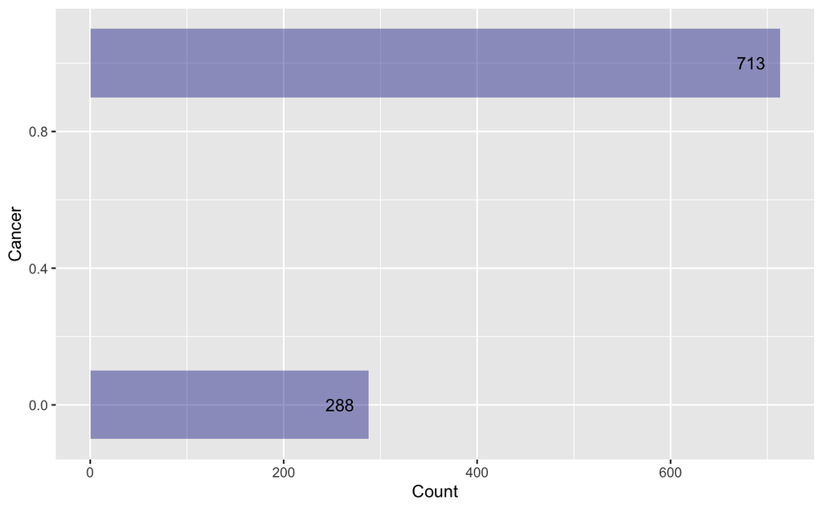

```r
ggplot(df, aes(y = POP)) +
  geom_bar(width=.2, fill="darkblue", alpha=0.4) +
  xlab("Count") +
  ylab("Cancer") +
  geom_text(stat='count', aes(label=..count..), hjust=1.5, vjust=.5)
```

## 6. Feature Selection

### 6.1 Correlation matrix

```r
df.cor <- df %>%
      mutate(POP = ifelse(POP == 1, 0, 1))
str(df.cor)
```

```
'data.frame':   1001 obs. of  4 variables:
 $ POP    : num  0 1 0 0 1 0 0 1 0 0 ...
 $ Dnu    : num  4.45 6.94 2.65 4.24 10.45 ...
 $ numax  : num  43.1 74.1 21.6 32.1 120.4 ...
 $ epsilon: num  0.985 0.15 0.855 0.84 0.275 0.945 0.985 0.215 0.885 0.855 ...
```

### 6.2 One-hot encoding

```r
# df.cor = df
# df.cor$diagnosis_result <- factor(df.cor$diagnosis_result,
#                  levels=c('M', 'B'),
#                  labels=c(0, 1))
# df.cor$diagnosis_result = as.numeric(df.cor$diagnosis_result)
```

### 6.3 Correlation heatmap

```r
cormat <- round(cor(select(df.cor, c("POP", "Dnu", "numax", "epsilon"))), 3)
# Merge data
melted_cormat = melt(cormat)
```

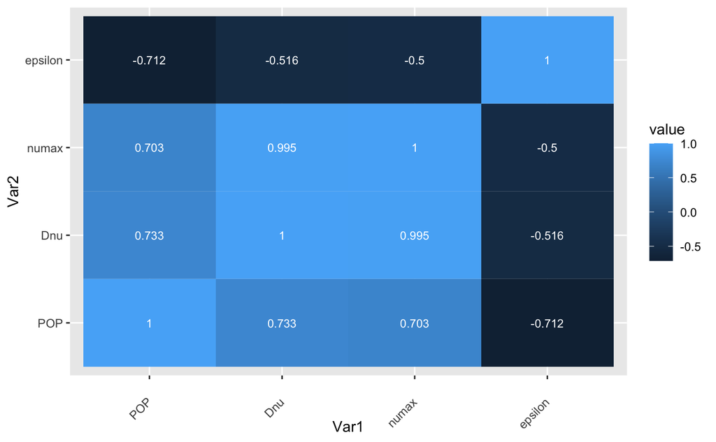

```r
ggplot(data=melted_cormat, aes(x=Var1, y=Var2, fill=value)) +
  geom_tile() +
  theme(axis.text.x=element_text(angle=45, hjust=1, vjust=.5)) +
  geom_text(aes(Var2, Var1, label = value),color='white', size=3)
```

What a perfect dataset! Strong correlations between independent variables and the dependent variable.

### 6.4 Feature selection

```r
# df.cor = subset(df.cor, select = -c(fractal_dimension, texture, perimeter) )
# str(df.cor)
```

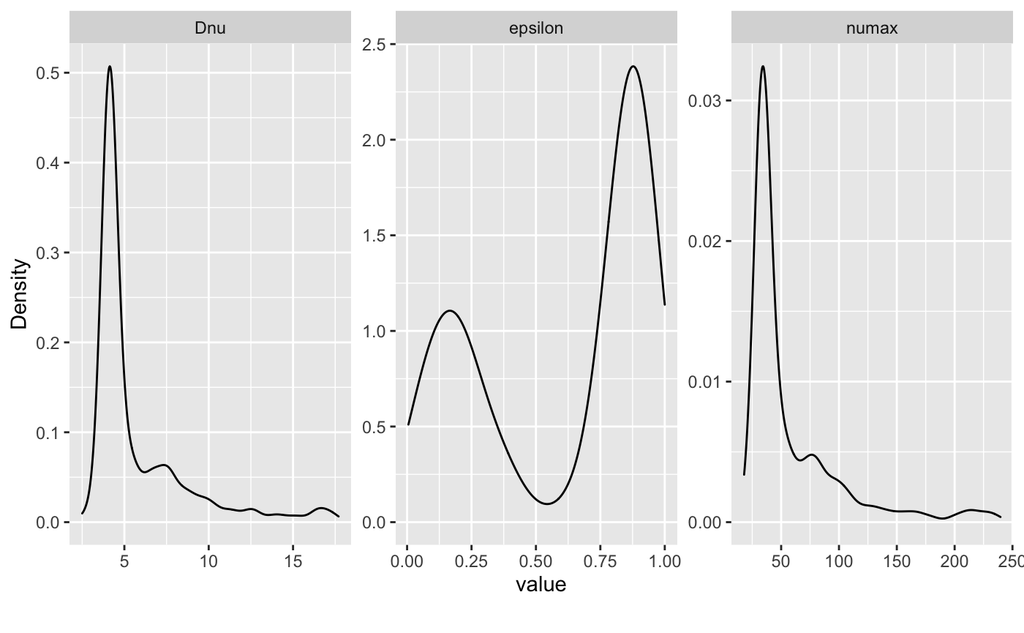

```r
plot_density(df)
```

Clearly, all the dimensions do not follow the Gaussian distribution.

## 7. Data Normalization

```r
# Normalization
min_max_norm <- function(x) {
      (x - min(x)) / (max(x) - min(x))
}
# df.norm = df.cor
df.norm <- as.data.frame(lapply(df, min_max_norm))
```

#### Notice that we use Min-Max normalization instead of Standardization for data rescaling for two reasons.First, we want to bound the data between 0 and 1. Also, all data doesn’t follow Gaussian Distribution. Their distributions are unkown to us.

```r
sum(is.na(df))
```

```
[1] 0
```

```r
summary(df.norm)
```

```
      POP              Dnu             numax            epsilon
 Min.   :0.0000   Min.   :0.0000   Min.   :0.00000   Min.   :0.0000
 1st Qu.:0.0000   1st Qu.:0.1035   1st Qu.:0.06742   1st Qu.:0.2161
 Median :1.0000   Median :0.1190   Median :0.09164   Median :0.8141
 Mean   :0.7123   Mean   :0.2155   Mean   :0.18253   Mean   :0.6088
 3rd Qu.:1.0000   3rd Qu.:0.2684   3rd Qu.:0.23531   3rd Qu.:0.8894
 Max.   :1.0000   Max.   :1.0000   Max.   :1.00000   Max.   :1.0000
```

## 8. Dataset Partitioning

We use 80% of the data set for training, and the rest for testing.

```r
# 80% of the sample size
smp_size <- floor(0.80 * nrow(df))
set.seed(123)
train_ind <- sample(seq_len(nrow(df.norm)), size = smp_size)
train <- df.norm[train_ind, ]
test <- df.norm[-train_ind, ]
```

### 8.1 Check data distribution

```r
prop.table(table(df.norm$POP))
```

```
        0         1
0.2877123 0.7122877
```

```r
prop.table(table(train$POP))
```

```
      0       1
0.27375 0.72625
```

```r
prop.table(table(test$POP))
```

```
        0         1
0.3432836 0.6567164
```

We can see that the training set and test set have similar label distributions as the original dataset.

## 9. Decision tree model

### 9.1 Plot decision tree model with ‘rpart’ package

```r
# Define decision trees model with 'rpart'
tree = rpart(POP~ ., data=train)
tree
```

```
n= 800

node), split, n, deviance, yval
      * denotes terminal node

 1) root 800 159.048700 0.72625000
   2) Dnu>=0.1938359 236  31.199150 0.15677970
     4) epsilon< 0.6457286 222  20.617120 0.10360360
       8) epsilon>=0.07035176 204   6.759804 0.03431373 *
       9) epsilon< 0.07035176 18   1.777778 0.88888890 *
     5) epsilon>=0.6457286 14   0.000000 1.00000000 *
   3) Dnu< 0.1938359 564  19.290780 0.96453900
     6) epsilon< 0.1758794 58  11.586210 0.72413790
      12) numax>=0.08612154 34   8.470588 0.52941180 *
      13) numax< 0.08612154 24   0.000000 1.00000000 *
     7) epsilon>=0.1758794 506   3.968379 0.99209490 *
```

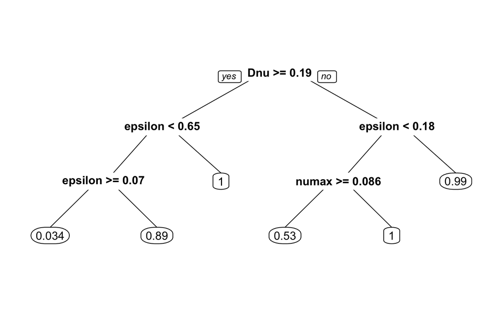

```r
prp(tree)
```

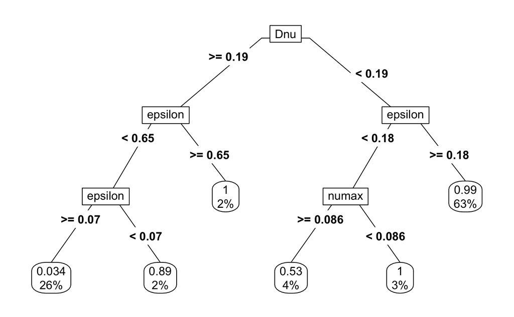

```r
prp (tree, type = 5, extra = 100)
```

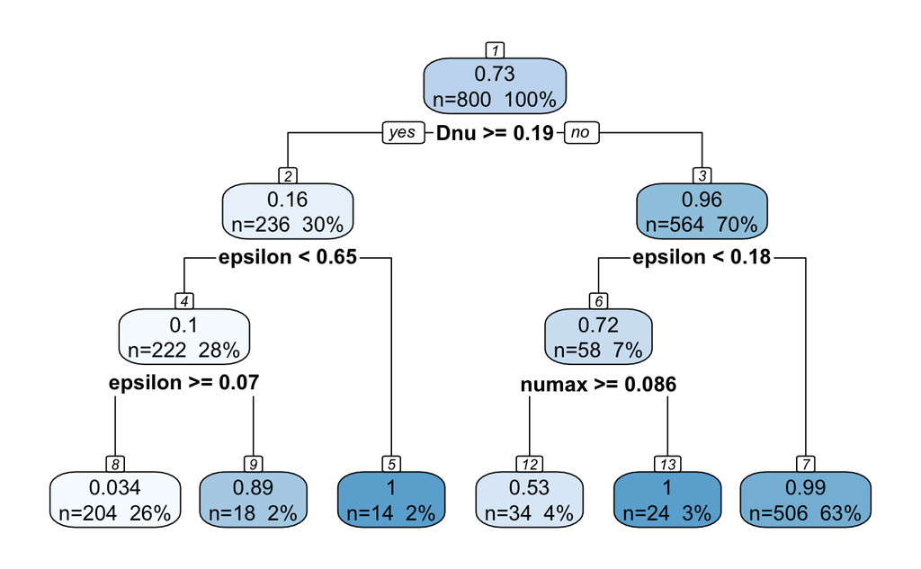

```r
rpart.plot(tree, extra = 101, nn = TRUE)
```

### 9.2 Plot decision tree model with ‘party’ package

```r
tree_party = ctree(POP~ ., data=train)
tree_party
```

```
     Conditional inference tree with 8 terminal nodes

Response:  POP
Inputs:  Dnu, numax, epsilon
Number of observations:  800

1) Dnu <= 0.1925753; criterion = 1, statistic = 441.507
  2) epsilon <= 0.1507538; criterion = 1, statistic = 83.452
    3) Dnu <= 0.1089507; criterion = 0.979, statistic = 7.22
      4)*  weights = 25
    3) Dnu > 0.1089507
      5)*  weights = 33
  2) epsilon > 0.1507538
    6) Dnu <= 0.06370996; criterion = 1, statistic = 20.956
      7)*  weights = 14
    6) Dnu > 0.06370996
      8)*  weights = 492
1) Dnu > 0.1925753
  9) epsilon <= 0.4723618; criterion = 1, statistic = 23.528
    10) epsilon <= 0.06532663; criterion = 1, statistic = 54.819
      11)*  weights = 18
    10) epsilon > 0.06532663
      12) epsilon <= 0.1005025; criterion = 0.992, statistic = 9
        13)*  weights = 11
      12) epsilon > 0.1005025
        14)*  weights = 193
  9) epsilon > 0.4723618
    15)*  weights = 14
```

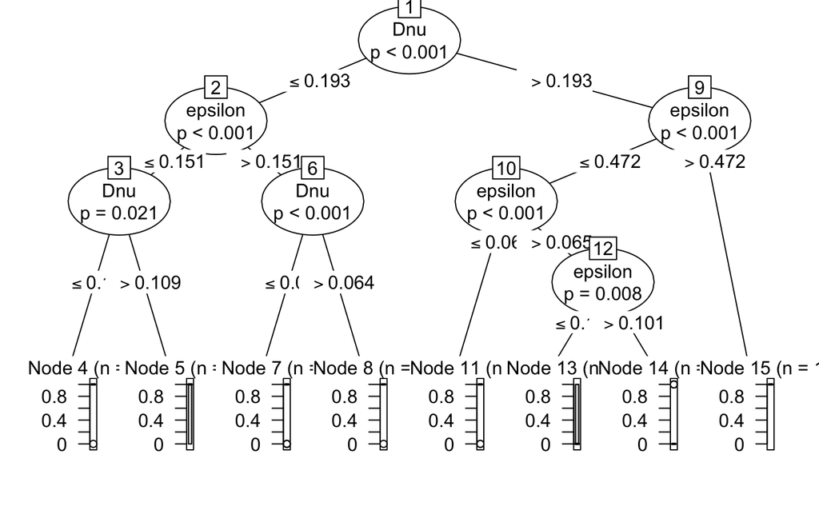

```r
plot(tree_party)
```

### 9.3 Split dataset with entropy information

```r
# Split with entropy information
ent_Tree = rpart(POP ~ ., data=train, method="class", parms=list(split="information"))
ent_Tree
```

```
n= 800

node), split, n, loss, yval, (yprob)
      * denotes terminal node

 1) root 800 219 1 (0.273750000 0.726250000)
   2) epsilon< 0.4949749 287  72 0 (0.749128920 0.250871080)
     4) epsilon>=0.1130653 203  13 0 (0.935960591 0.064039409)
       8) Dnu>=0.1757259 192   3 0 (0.984375000 0.015625000) *
       9) Dnu< 0.1757259 11   1 1 (0.090909091 0.909090909) *
     5) epsilon< 0.1130653 84  25 1 (0.297619048 0.702380952)
      10) numax>=0.08612154 62  25 1 (0.403225806 0.596774194)
        20) numax< 0.2371573 45  21 0 (0.533333333 0.466666667)
          40) epsilon>=0.07286432 16   3 0 (0.812500000 0.187500000) *
          41) epsilon< 0.07286432 29  11 1 (0.379310345 0.620689655)
            82) numax< 0.1094143 7   2 0 (0.714285714 0.285714286) *
            83) numax>=0.1094143 22   6 1 (0.272727273 0.727272727) *
        21) numax>=0.2371573 17   1 1 (0.058823529 0.941176471) *
      11) numax< 0.08612154 22   0 1 (0.000000000 1.000000000) *
   3) epsilon>=0.4949749 513   4 1 (0.007797271 0.992202729) *
```

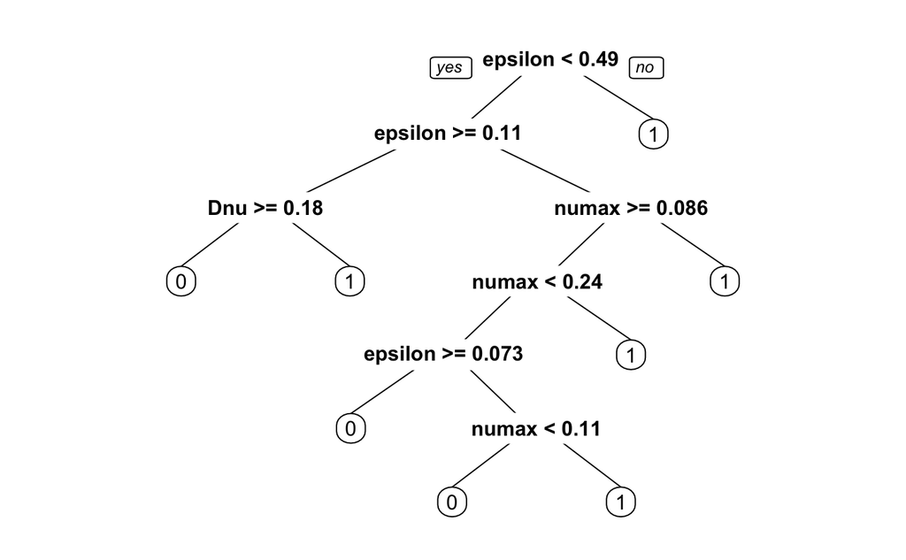

```r
prp(ent_Tree)
```

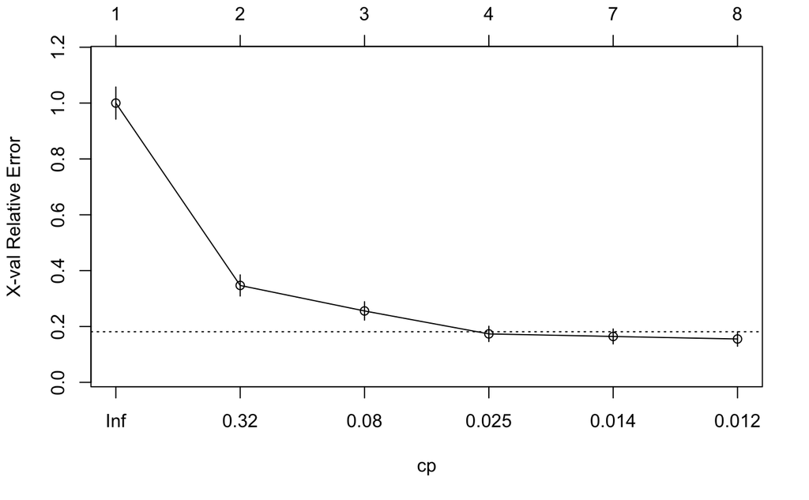

```r
plotcp(ent_Tree)
```

### 9.4 Create decision trees model with parameter settings

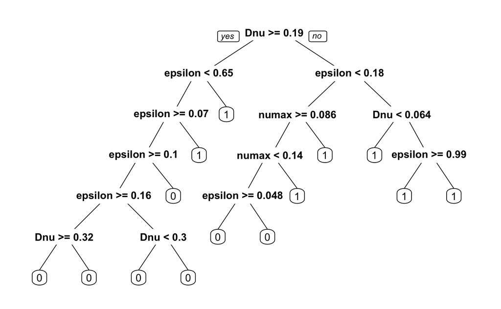

```r
tree_with_params = rpart(POP ~ ., data=train, method="class", minsplit = 1, minbucket = 10, cp = -1)
prp (tree_with_params)
```

```r
print(tree_with_params)
```

```
n= 800

node), split, n, loss, yval, (yprob)
      * denotes terminal node

 1) root 800 219 1 (0.273750000 0.726250000)
   2) Dnu>=0.1938359 236  37 0 (0.843220339 0.156779661)
     4) epsilon< 0.6457286 222  23 0 (0.896396396 0.103603604)
       8) epsilon>=0.07035176 204   7 0 (0.965686275 0.034313725)
        16) epsilon>=0.1030151 193   3 0 (0.984455959 0.015544041)
          32) epsilon>=0.1633166 150   1 0 (0.993333333 0.006666667)
            64) Dnu>=0.3185656 140   0 0 (1.000000000 0.000000000) *
            65) Dnu< 0.3185656 10   1 0 (0.900000000 0.100000000) *
          33) epsilon< 0.1633166 43   2 0 (0.953488372 0.046511628)
            66) Dnu< 0.2984841 33   0 0 (1.000000000 0.000000000) *
            67) Dnu>=0.2984841 10   2 0 (0.800000000 0.200000000) *
        17) epsilon< 0.1030151 11   4 0 (0.636363636 0.363636364) *
       9) epsilon< 0.07035176 18   2 1 (0.111111111 0.888888889) *
     5) epsilon>=0.6457286 14   0 1 (0.000000000 1.000000000) *
   3) Dnu< 0.1938359 564  20 1 (0.035460993 0.964539007)
     6) epsilon< 0.1758794 58  16 1 (0.275862069 0.724137931)
      12) numax>=0.08612154 34  16 1 (0.470588235 0.529411765)
        24) numax< 0.1425395 21   8 0 (0.619047619 0.380952381)
          48) epsilon>=0.04773869 11   3 0 (0.727272727 0.272727273) *
          49) epsilon< 0.04773869 10   5 0 (0.500000000 0.500000000) *
        25) numax>=0.1425395 13   3 1 (0.230769231 0.769230769) *
      13) numax< 0.08612154 24   0 1 (0.000000000 1.000000000) *
     7) epsilon>=0.1758794 506   4 1 (0.007905138 0.992094862)
      14) Dnu< 0.06376095 14   3 1 (0.214285714 0.785714286) *
      15) Dnu>=0.06376095 492   1 1 (0.002032520 0.997967480)
        30) epsilon>=0.9924623 10   1 1 (0.100000000 0.900000000) *
        31) epsilon< 0.9924623 482   0 1 (0.000000000 1.000000000) *
```

```r
summary(tree_with_params)
```

```
Call:
rpart(formula = POP ~ ., data = train, method = "class", minsplit = 1,
    minbucket = 10, cp = -1)
  n= 800

           CP nsplit rel error    xerror       xstd
1  0.73972603      0 1.0000000 1.0000000 0.05758654
2  0.06392694      1 0.2602740 0.2785388 0.03427662
3  0.00761035      3 0.1324201 0.1461187 0.02530850
4  0.00000000      6 0.1095890 0.1552511 0.02605342
5 -1.00000000     13 0.1095890 0.1552511 0.02605342

Variable importance
    Dnu   numax epsilon
     35      33      31

Node number 1: 800 observations,    complexity param=0.739726
  predicted class=1  expected loss=0.27375  P(node) =1
    class counts:   219   581
   probabilities: 0.274 0.726
  left son=2 (236 obs) right son=3 (564 obs)
  Primary splits:
      Dnu     < 0.1938359  to the right, improve=217.1176, (0 missing)
      epsilon < 0.4949749  to the left,  improve=202.2853, (0 missing)
      numax   < 0.1853062  to the right, improve=196.3368, (0 missing)
  Surrogate splits:
      numax   < 0.1746628  to the right, agree=0.981, adj=0.936, (0 split)
      epsilon < 0.4949749  to the left,  agree=0.901, adj=0.665, (0 split)

Node number 2: 236 observations,    complexity param=0.06392694
  predicted class=0  expected loss=0.1567797  P(node) =0.295
    class counts:   199    37
   probabilities: 0.843 0.157
  left son=4 (222 obs) right son=5 (14 obs)
  Primary splits:
      epsilon < 0.6457286  to the left,  improve=21.164070, (0 missing)
      Dnu     < 0.3878242  to the right, improve= 9.319388, (0 missing)
      numax   < 0.3991821  to the right, improve= 5.363578, (0 missing)

Node number 3: 564 observations,    complexity param=0.00761035
```

[output cut: 67 more lines]

```

Node number 13: 24 observations
  predicted class=1  expected loss=0  P(node) =0.03
    class counts:     0    24
   probabilities: 0.000 1.000

Node number 24: 21 observations,    complexity param=0
  predicted class=0  expected loss=0.3809524  P(node) =0.02625
    class counts:    13     8
   probabilities: 0.619 0.381

Node number 25: 13 observations
  predicted class=1  expected loss=0.2307692  P(node) =0.01625
    class counts:     3    10
   probabilities: 0.231 0.769
```

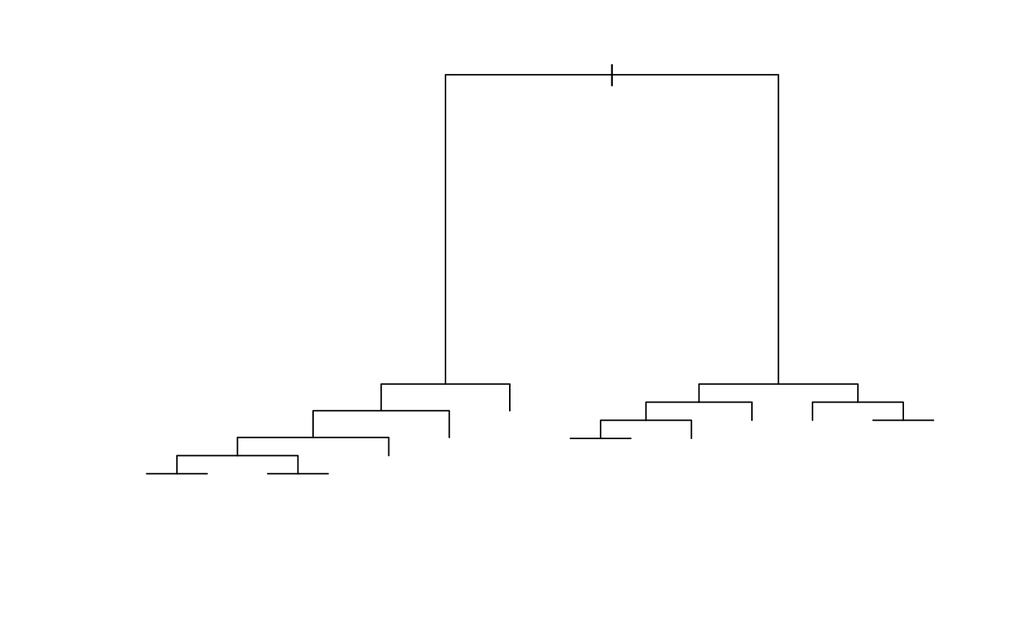

```r
plot(tree_with_params)
```

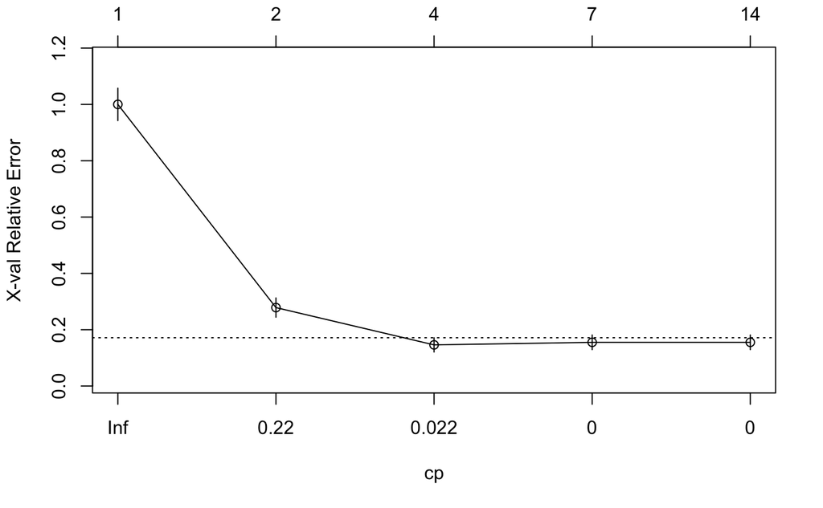

```r
plotcp(tree_with_params)
```

### 9.5 Predict and evaluate the performance of the trained tree model

```r
# Examine the values of Predict, which are the class probabilities.
Predict = predict(tree_with_params, test)
```

```r
Predict = predict(tree_with_params, test, type = "class")
```

```r
# Producing confusion matrix
Confusion_matrix = table(Predict, test$POP)
Confusion_matrix
```

```
Predict   0   1
      0  67   9
      1   2 123
```

```r
# Calculating the accuracy using the confusion matrix
Accuracy = sum(diag(Confusion_matrix))/sum(Confusion_matrix)
Accuracy
```

```
[1] 0.9452736
```

## 10. AUC & ROC Analysis

```r
# To draw ROC we need to predict the prob values. So we run predict again
# Note that PredictROC is same as Predict with "type = prob"
Predict_ROC = predict(tree_with_params, test)
# Predict_ROC
# Predict_ROC[,2]
```

```r
pred = prediction(Predict_ROC[,2], test$POP)
perf = performance(pred, "tpr", "fpr")
```

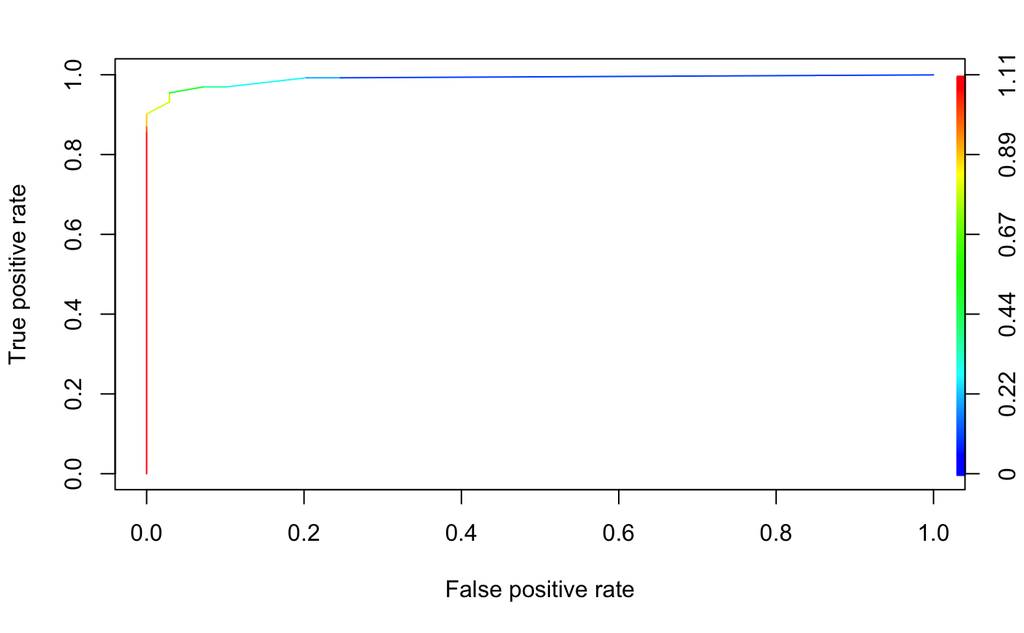

```r
plot(perf, colorize = T)
```

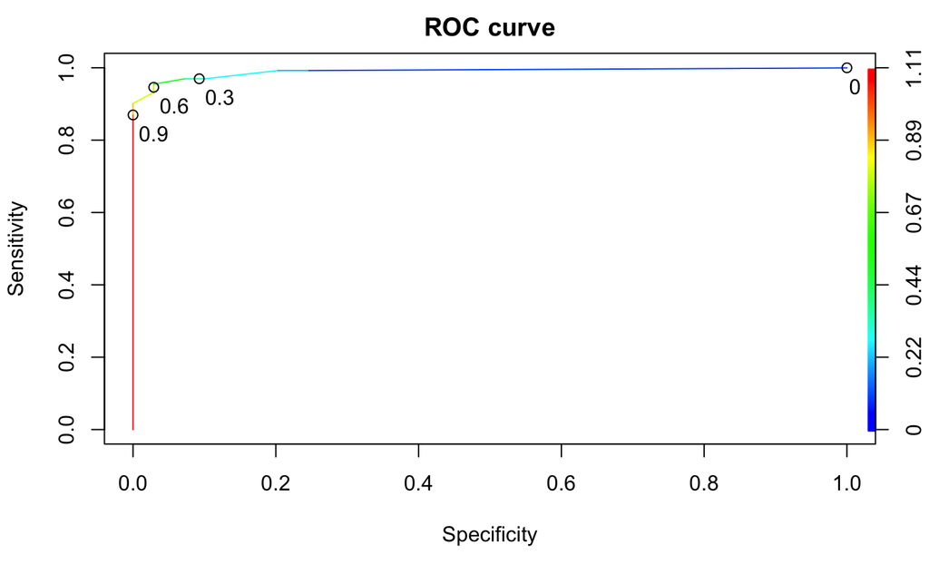

```r
plot(perf, colorize=T,
     main = "ROC curve",
     ylab = "Sensitivity",
     xlab = "Specificity",
     print.cutoffs.at=seq(0,1,0.3),
     text.adj= c(-0.2,1.7))
```

```r
# Area Under Curve
auc = as.numeric(performance(pred, "auc")@y.values)
auc = round(auc, 3)
auc
```

```
[1] 0.99
```

```r
cat("Last Block!")
```